# What the package does

```r
library(MATH4753ALI24)
```

# Introduction:

# Function 1: meanclt (mean central limit theorem)

This function generates random numbers from a uniform distribution, calculates the mean of each iteration, and plots a histogram of the sample means.

```r
library(MATH4753ALI24)
meancltVar = MATH4753ALI24::meanclt(n = 10, iter = 10000)
```

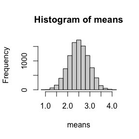

# Function 2: randsample

This function makes random samples of size n between 1:10 with replacement, and makes a factor based on frequency of each number in the sample. Then, it makes a bar plot based on this factor. Below we generate 3 iterations of sample size n=20:

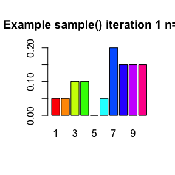

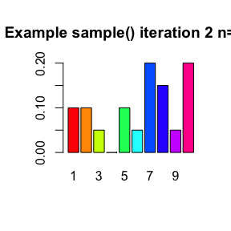

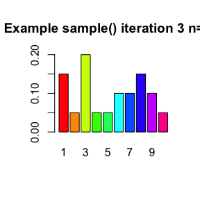

```r
MATH4753ALI24::randsample(20, iter = 3)
```

# Function 3:

This function finds the parameter value that maximizes the likelihood function. Here we create the function logbin2, and pass it to the mymaxlikg function:

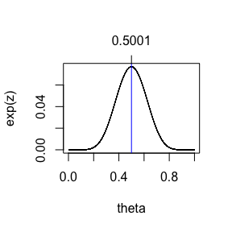

```
#> [1] 0.50005
```

```r
logbin2 <- function(theta) {
    log(dbinom(3, prob = theta, size = 6)) +
    log(dbinom(5, prob = theta, size = 10))
}
MATH4753ALI24::mymaxlikg(theta = seq(0, 1, length = 10000), lfun = logbin2)
```

# Function 4:

This function creates a normal curve based on a given mean, standard deviation, and limit for the probability calculation, which will be <= a. In this example, the mean is 5, the standard deviation is 10, and a is 3:

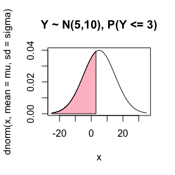

```
#> $mu
#> [1] 5
#>
#> $sigma
#> [1] 10
#>
#> $area
#> [1] 0.4207
```

```r
MATH4753ALI24::myncurve(5, 10, 3)
```

# Dataset: fire

fire is a data set collected concerning home damage from fire. It holds two variables: DISTANCE, which is the distance of a house fire from a fire station (in miles), and DAMAGE, which is the damage incurred from the house fire (in thousands of dollars). Below are the first 6 rows of this data set that has 15 rows total.

```r
head(MATH4753ALI24::fire)
```

```
#>   DISTANCE DAMAGE
#> 1      3.4   26.2
#> 2      1.8   17.8
#> 3      4.6   31.3
#> 4      2.3   23.1
#> 5      3.1   27.5
#> 6      5.5   36.0
```